# Principal Component Analysis

Dataset seagrass.red.scaled

This dataset contains 88 individuals and 4 variables, 1 qualitative variable is considered as illustrative.

### 1. Inertia distribution

The inertia of the first dimensions shows if there are strong relationships between variables and suggests the number of dimensions that should be studied.

The first two dimensions of PCA express **78.37%** of the total dataset inertia ; that means that 78.37% of the individuals (or variables) cloud total variability is explained by the plane. This percentage is high and thus the first plane represents an important part of the data variability. This value is greater than the reference value that equals **77.8%**, the variability explained by this plane is thus significant (the reference value is the 0.95-quantile of the inertia percentages distribution obtained by simulating 825 data tables of equivalent size on the basis of a normal distribution).

From these observations, it is probably not useful to interpret the next dimensions.

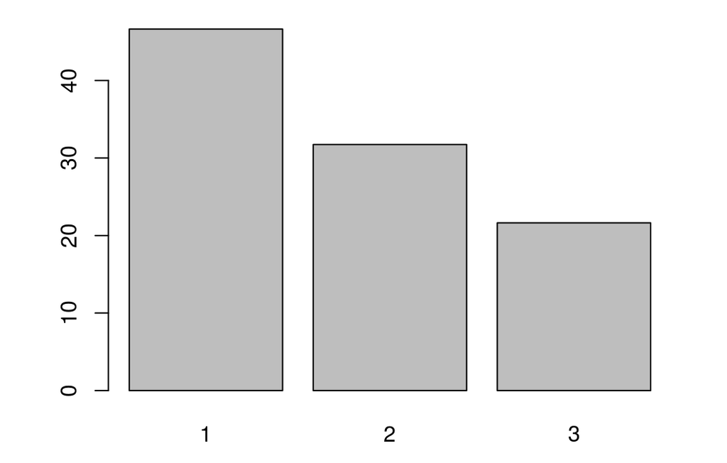

**Figure 1 - Decomposition of the total inertia on the components of the PCA**

An estimation of the right number of axis to interpret suggests to restrict the analysis to the description of the first 1 axis. These axis present an amount of inertia greater than those obtained by the 0.95-quantile of random distributions (46.63% against 45.68%). This observation suggests that only this axis is carrying a real information. As a consequence, the description will stand to these axis.

### 2. Description of the dimension 1

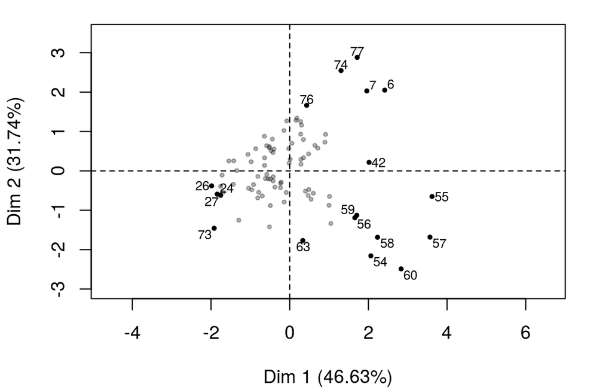

**Figure 2.1 - Individuals factor map (PCA)** *The labeled individuals are those with the higher contribution to the plane construction.*

The Wilks test p-value indicates which variable factors are the best separated on the plane (i.e. which one explain the best the distance between individuals).

```
##      station
## 4.345598e-05
```

There only is one possible qualitative variable to illustrate the distance between individuals : *station*.

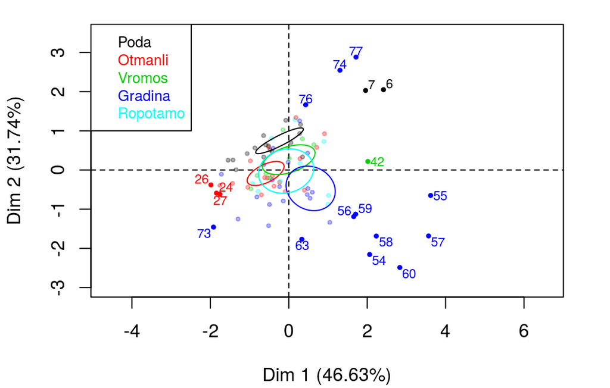

**Figure 2.2 - Individuals factor map (PCA)** *The labeled individuals are those with the higher contribution to the plane construction.* *The individuals are coloured after their category for the variable* station.

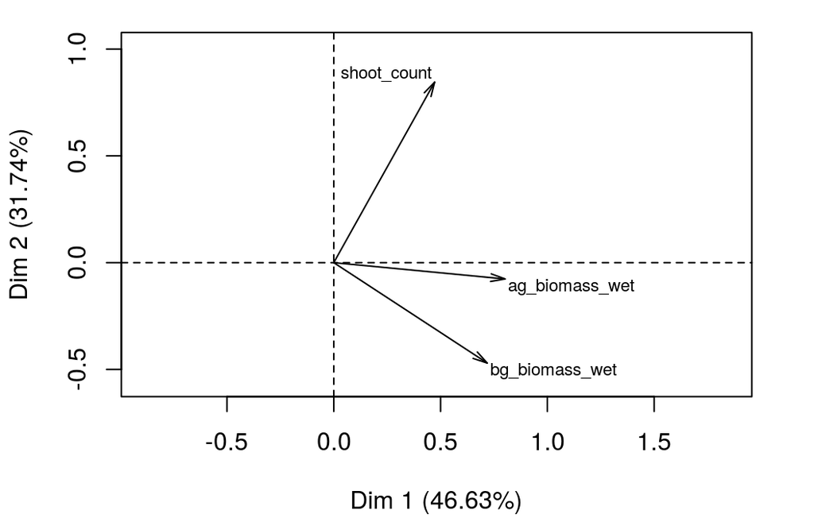

**Figure 2.3 - Variables factor map (PCA)** *The labeled variables are those the best shown on the plane.*

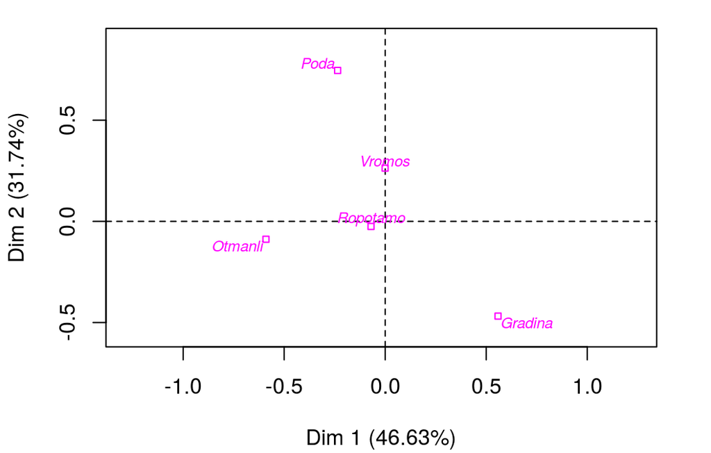

**Figure 2.4 - Qualitative factor map (PCA)** *The labeled factors are those the best shown on the plane.*

The group in which the individuals *7*, *77*, *74*, *76* and *6* stand (characterized by a positive coordinate on the axis) is sharing :

- high values for the variable *shoot_count*.

The group in which the individuals *59*, *56*, *42*, *57*, *58*, *55* and *60* stand (characterized by a positive coordinate on the axis) is sharing :

- high values for the variables *bg_biomass_wet* and *ag_biomass_wet* (variables are sorted from the strongest).

The group in which the individuals *24*, *27*, *26* and *73* stand (characterized by a negative coordinate on the axis) is sharing :

- low values for the variables *ag_biomass_wet*, *bg_biomass_wet* and *shoot_count* (variables are sorted from the weakest).

### 3. Classification

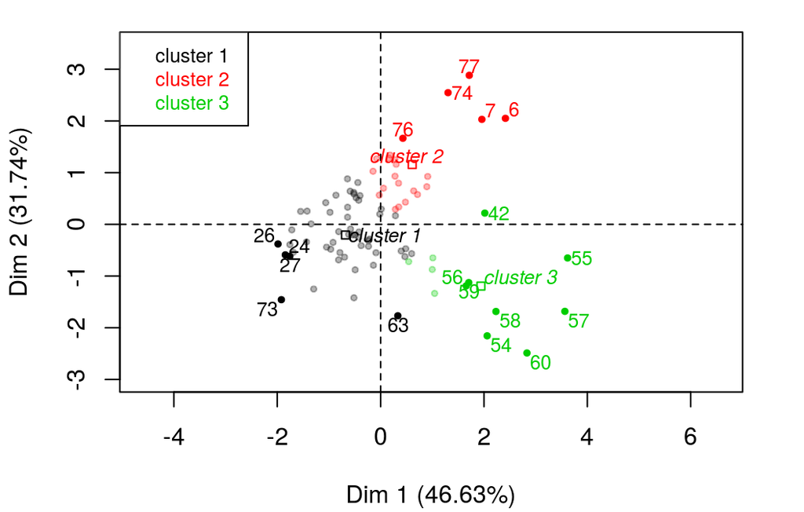

**Figure 3 - Ascending Hierarchical Classification of the individuals.** *The classification made on individuals reveals 3 clusters.*

The **cluster 1** is made of individuals such as *24*, *26*, *27*, *63* and *73*. This group is characterized by :

- low values for the variables *ag_biomass_wet*, *shoot_count* and *bg_biomass_wet* (variables are sorted from the weakest).

The **cluster 2** is made of individuals such as *6*, *7*, *74*, *76* and *77*. This group is characterized by :

- high values for the variable *shoot_count*.

The **cluster 3** is made of individuals such as *42*, *54*, *55*, *56*, *57*, *58*, *59* and *60*. This group is characterized by :

- high values for the variables *ag_biomass_wet* and *bg_biomass_wet* (variables are sorted from the strongest).

## Annexes

```r
dimdesc(res, axes = 1:1)
```

```
$Dim.1
$Dim.1$quanti
               correlation      p.value
ag_biomass_wet   0.8069975 2.250790e-21
bg_biomass_wet   0.7225112 1.926181e-15
shoot_count      0.4749595 2.931143e-06

$Dim.1$quali
               R2    p.value
station 0.1427295 0.01160658

$Dim.1$category
          Estimate    p.value
Gradina  0.6260395 0.00112888
Otmanli -0.5226051 0.01030135
```

**Figure 4 - List of variables characterizing the dimensions of the analysis.**

```r
res.hcpc$desc.var
```

```
Link between the cluster variable and the categorical variables (chi-square test)
=================================================================================
           p.value df
station 0.03515379  8

Description of each cluster by the categories
=============================================
$`1`
NULL

$`2`
NULL

$`3`
                Cla/Mod Mod/Cla   Global     p.value    v.test
station=Gradina      30      75 34.09091 0.002664922  3.003958
station=Otmanli       0       0 22.72727 0.035457753 -2.103092


Link between the cluster variable and the quantitative variables
================================================================
                    Eta2      P-value
shoot_count    0.5637360 4.890441e-16
ag_biomass_wet 0.5282684 1.355305e-14
bg_biomass_wet 0.3914488 6.801864e-10

Description of each cluster by quantitative variables
=====================================================
$`1`
                  v.test Mean in category  Overall mean sd in category
bg_biomass_wet -3.590748       -0.3037289  1.549423e-17      0.7518526
shoot_count    -5.284748       -0.4470185 -1.377134e-16      0.5638583
ag_biomass_wet -5.463779       -0.4621621 -4.555128e-17      0.4368156
               Overall sd      p.value
bg_biomass_wet  0.9943019 3.297306e-04
shoot_count     0.9943019 1.258781e-07
ag_biomass_wet  0.9943019 4.661043e-08

$`2`
              v.test Mean in category  Overall mean sd in category
shoot_count 6.997546         1.292007 -1.377134e-16       0.833307
            Overall sd      p.value
shoot_count  0.9943019 2.604853e-12

$`3`
                 v.test Mean in category  Overall mean sd in category
ag_biomass_wet 6.209929         1.665948 -4.555128e-17       1.129964
bg_biomass_wet 5.780054         1.550625  1.549423e-17       1.130064
               Overall sd      p.value
ag_biomass_wet  0.9943019 5.300839e-10
bg_biomass_wet  0.9943019 7.467665e-09
```

**Figure 5 - List of variables characterizing the clusters of the classification.**